# 02_GSEA_pathway_analyses

Ralitsa R. Madsen

UCL

# Readme

This notebook should only be run after “01_Differential_gene_expression_analysis.Rmd” has been run, with access to the same Global Environment.

# Setup

```r
knitr::opts_chunk$set(echo = T, warning = F, message = F) # setting global chunk options for knitted output
#source("scripts/install.packages.R") # installs all required packages; uncomment and run if not done once already
source("scripts/packages.R") # loads the required packages
```

```r
input.data <- file.path(getwd(), "data_input/")
output.figures <- file.path(getwd(), "figures_output/")
output.df <- file.path(getwd(), "data_output/")
options("scipen"=5, "digits"=4) # control scientific notation, in this case triggered only when number is 10 digits
```

# GSEA testing with fgsea

Reference: Sergushichev, A.A., 2016. An algorithm for fast preranked gene set enrichment analysis using cumulative statistic calculation. bioRxiv 060012.

#### Retrieve relevant gene sets

Hallmark gene sets from mSigDb

```r
m_df <- msigdbr(species = "Homo sapiens", category = "H")
```

```r
m_df1 <- m_df %>% dplyr::select(gs_name, human_gene_symbol)
```

```r
unique.gs.h <- unique(m_df1$gs_name)
length <- length(unique.gs.h)
hallmark.gs <- vector(mode = "list", length = length)
```

```r
m_df1[m_df1$gs_name %in% unique.gs.h[1],]
```

| gs_name | human_gene_symbol |
| --- | --- |
| HALLMARK_ADIPOGENESIS | ABCA1 |
| HALLMARK_ADIPOGENESIS | ABCB8 |
| HALLMARK_ADIPOGENESIS | ACAA2 |
| HALLMARK_ADIPOGENESIS | ACADL |
| HALLMARK_ADIPOGENESIS | ACADM |
| HALLMARK_ADIPOGENESIS | ACADS |
| HALLMARK_ADIPOGENESIS | ACLY |
| HALLMARK_ADIPOGENESIS | ACO2 |
| HALLMARK_ADIPOGENESIS | ACOX1 |
| HALLMARK_ADIPOGENESIS | ADCY6 |

[output cut: 198 more lines]

Create a list of the hallmark gene sets

```r
for (gs in 1:length) {
  gene.set.h <- unique.gs.h[gs] # pull out signature name
  names(hallmark.gs)[gs] <- gene.set.h # assign signature name to list components
  hallmark.gs[[gs]] <- m_df1$human_gene_symbol[m_df1$gs_name %in% gene.set.h] # assign signature gene ids to the respective list component
}
```

```r
length(hallmark.gs)
```

```
[1] 50
```

## Create vectors of gene expression values from the different lists of differentially expressed genes

NB: these vectors won’t be ranked manually as this happens during the fgsea run itself.

- First make sure that any ENSGs resulting in duplicate HGNCs are removed to avoid ambiguity in the subsequent fgsea analysis

```r
length(de.data.annot$HGNC[duplicated(de.data.annot$HGNC)]) # 4120
```

```
[1] 4120
```

- Confirm that these duplications do not reflect duplications at the ENSG level

```r
length(de.data.annot$Genes[duplicated(de.data.annot$Genes)]) # 0, i.e. no ENSG duplications
```

```
[1] 0
```

- Extract the duplicated genes

```r
dupl <- unique(de.data.annot$HGNC[duplicated(de.data.annot$HGNC)]) # actually only 1 real duplication = TBCE; the rest come from missing annotations
de.data.annot.no.dupl <- de.data.annot %>%
  filter(!(HGNC %in% dupl))
```

```r
# KOvsWT
de.data.annot.KOvsWT.rank <- de.data.annot.no.dupl %>%
  dplyr::select(HGNC, t.KOvsWT) %>%
  filter(HGNC != "") %>% # already removed, but included from external code snippet
  filter(!is.na(HGNC))
de.data.annot.KOvsWT.rank.vector <- tibble::deframe(de.data.annot.KOvsWT.rank)
```

```r
head(de.data.annot.KOvsWT.rank.vector)
```

```
  TSPAN6     DPM1    SCYL3 C1orf112      CFH    FUCA2
 -10.064    7.303   -0.024   -6.989    2.497    1.239
```

```r
# WT INH1vsVEH
de.data.annot.WT_INH1vsVEH.rank <- de.data.annot.no.dupl %>%
  dplyr::select(HGNC, t.WT_INH1) %>%
  filter(HGNC != "") %>% # already removed, but included from external code snippet
  filter(!is.na(HGNC))
de.data.annot.WT_INH1vsVEH.rank.vector <- tibble::deframe(de.data.annot.WT_INH1vsVEH.rank)
```

```r
head(de.data.annot.WT_INH1vsVEH.rank.vector)
```

```
  TSPAN6     DPM1    SCYL3 C1orf112      CFH    FUCA2
 5.52046 -3.87335  0.02792 -4.80162  4.04545 -4.21015
```

```r
# WT INH2vsVEH
de.data.annot.WT_INH2vsVEH.rank <- de.data.annot.no.dupl %>%
  dplyr::select(HGNC, t.WT_INH2) %>%
  filter(HGNC != "") %>% # already removed, but included from external code snippet
  filter(!is.na(HGNC))
de.data.annot.WT_INH2vsVEH.rank.vector <- tibble::deframe(de.data.annot.WT_INH2vsVEH.rank)
```

```r
head(de.data.annot.WT_INH2vsVEH.rank.vector)
```

```
  TSPAN6     DPM1    SCYL3 C1orf112      CFH    FUCA2
  3.4005   1.4796  -1.4136   1.2709   1.3478   0.3716
```

```r
# KO INH1vsVEH
de.data.annot.KO_INH1vsVEH.rank <- de.data.annot.no.dupl %>%
  dplyr::select(HGNC, t.KO_INH1) %>%
  filter(HGNC != "") %>% # already removed, but included from external code snippet
  filter(!is.na(HGNC))
de.data.annot.KO_INH1vsVEH.rank.vector <- tibble::deframe(de.data.annot.KO_INH1vsVEH.rank)
```

```r
head(de.data.annot.KO_INH1vsVEH.rank.vector)
```

```
  TSPAN6     DPM1    SCYL3 C1orf112      CFH    FUCA2
  4.1798  -4.6600   0.1475  -7.2472   3.9287  -6.5702
```

```r
# KO INH2vsVEH
de.data.annot.KO_INH2vsVEH.rank <- de.data.annot.no.dupl %>%
  dplyr::select(HGNC, t.KO_INH2) %>%
  filter(HGNC != "") %>% # already removed, but included from external code snippet
  filter(!is.na(HGNC))
de.data.annot.KO_INH2vsVEH.rank.vector <- tibble::deframe(de.data.annot.KO_INH2vsVEH.rank)
```

```r
head(de.data.annot.KO_INH2vsVEH.rank.vector)
```

```
  TSPAN6     DPM1    SCYL3 C1orf112      CFH    FUCA2
 2.66714  1.03788  0.86042 -3.40564  1.75354  0.03091
```

### fgsea run

Using updated approach where default is fgseaMultilevel

Not focusing on INH2 due to small t values, i.e. very few differentially expressed genes across the two genotypes.

##### KOvsWT

```r
fgsea.de.data.annot.KOvsWT <- fgsea(pathways = hallmark.gs,
                  stats = de.data.annot.KOvsWT.rank.vector,
                  minSize=15,
                  maxSize=500)
```

```r
fgsea.de.data.annot.KOvsWT %>%
  arrange(padj)
```

| pathway | pval | padj | log2err | ES | NES | size | leadingEdge |
| --- | --- | --- | --- | --- | --- | --- | --- |
| HALLMARK_E2F_TARGETS | 0.00004316 | 0.002158 | 0.55733 | -0.4245 | -1.6724 | 198 |  |
| HALLMARK_MYOGENESIS | 0.00297734 | 0.074433 | 0.43171 | 0.3861 | 1.5263 | 142 |  |
| HALLMARK_APICAL_JUNCTION | 0.01823866 | 0.115542 | 0.35249 | 0.3328 | 1.3421 | 162 |  |
| HALLMARK_CHOLESTEROL_HOMEOSTASIS | 0.01120074 | 0.115542 | 0.38073 | 0.4414 | 1.5466 | 68 |  |
| HALLMARK_EPITHELIAL_MESENCHYMAL_TRANSITION | 0.01598584 | 0.115542 | 0.35249 | -0.3448 | -1.3429 | 187 |  |
| HALLMARK_GLYCOLYSIS | 0.01574178 | 0.115542 | 0.35249 | -0.3583 | -1.3773 | 173 |  |
| HALLMARK_HYPOXIA | 0.01848669 | 0.115542 | 0.35249 | -0.3468 | -1.3358 | 175 |  |
| HALLMARK_MYC_TARGETS_V2 | 0.01628478 | 0.115542 | 0.35249 | -0.4708 | -1.5279 | 57 |  |
| HALLMARK_UV_RESPONSE_DN | 0.02697530 | 0.149863 | 0.35249 | 0.3344 | 1.3236 | 141 |  |
| HALLMARK_MYC_TARGETS_V1 | 0.03274639 | 0.163732 | 0.32178 | -0.3292 | -1.2971 | 199 |  |

[output cut: 40 more lines]

Make table plot

```r
topPathwaysUp.KOvsWT <- fgsea.de.data.annot.KOvsWT[ES > 0][head(order(pval), n=10), pathway]
topPathwaysDown.KOvsWT <- fgsea.de.data.annot.KOvsWT[ES < 0][head(order(pval), n=10), pathway]
topPathways.KOvsWT <- c(topPathwaysUp.KOvsWT, rev(topPathwaysDown.KOvsWT))
png(paste0(output.figures, Sys.Date(), sep="_", "GSEA_KOvsWT", ".png"),
    height=1500, width=3500, res=300)
plotGseaTable(hallmark.gs[topPathways.KOvsWT],
              de.data.annot.KOvsWT.rank.vector,
              fgsea.de.data.annot.KOvsWT,
              gseaParam = 0.5)
dev.off()
```

```r
fgsea.de.data.annot.KOvsWT$Condition <- "KOvsWT" # required for heatmap
```

##### WT INH1vsVEH

```r
fgsea.de.data.annot.WT.INH1vsVEH <- fgsea(pathways = hallmark.gs,
                  stats = de.data.annot.WT_INH1vsVEH.rank.vector,
                  minSize=15,
                  maxSize=500)
```

```r
fgsea.de.data.annot.WT.INH1vsVEH %>%
  arrange(padj)
```

| pathway | pval | padj | log2err | ES | NES | size | leadingEdge |
| --- | --- | --- | --- | --- | --- | --- | --- |
| HALLMARK_E2F_TARGETS | 1.000e-10 | 7.143e-10 | NA | -0.7097 | -3.2624 | 198 |  |
| HALLMARK_EPITHELIAL_MESENCHYMAL_TRANSITION | 1.000e-10 | 7.143e-10 | NA | 0.5621 | 2.5229 | 187 |  |
| HALLMARK_G2M_CHECKPOINT | 1.000e-10 | 7.143e-10 | NA | -0.6552 | -3.0031 | 197 |  |
| HALLMARK_HYPOXIA | 1.000e-10 | 7.143e-10 | NA | 0.6446 | 2.8662 | 175 |  |
| HALLMARK_MYC_TARGETS_V1 | 1.000e-10 | 7.143e-10 | NA | -0.7586 | -3.4918 | 199 |  |
| HALLMARK_MYC_TARGETS_V2 | 1.000e-10 | 7.143e-10 | NA | -0.6895 | -2.6330 | 57 |  |
| HALLMARK_MYOGENESIS | 1.000e-10 | 7.143e-10 | NA | 0.5451 | 2.3651 | 142 |  |
| HALLMARK_OXIDATIVE_PHOSPHORYLATION | 4.526e-10 | 2.829e-09 | 0.81404 | -0.4601 | -2.1177 | 199 |  |
| HALLMARK_MTORC1_SIGNALING | 3.306e-09 | 1.837e-08 | 0.77494 | -0.4389 | -2.0118 | 197 |  |
| HALLMARK_COAGULATION | 6.254e-09 | 3.127e-08 | 0.76146 | 0.5636 | 2.3221 | 98 |  |

[output cut: 40 more lines]

Make table plot

```r
topPathwaysUp.WT.INH1vsVEH <- fgsea.de.data.annot.WT.INH1vsVEH[ES > 0][head(order(pval), n=10), pathway]
topPathwaysDown.WT.INH1vsVEH <- fgsea.de.data.annot.WT.INH1vsVEH[ES < 0][head(order(pval), n=10), pathway]
topPathways.WT.INH1vsVEH <- c(topPathwaysUp.WT.INH1vsVEH, rev(topPathwaysDown.WT.INH1vsVEH))
png(paste0(output.figures, Sys.Date(), sep="_", "GSEA_WT_INH1vsVEH", ".png"),
    height=1500, width=3500, res=300)
plotGseaTable(hallmark.gs[topPathways.WT.INH1vsVEH],
              de.data.annot.WT_INH1vsVEH.rank.vector,
              fgsea.de.data.annot.WT.INH1vsVEH,
              gseaParam = 0.5)
dev.off()
```

```r
fgsea.de.data.annot.WT.INH1vsVEH$Condition <- "WT.INH1vsVEH" # required for heatmap
```

##### KO INH1vsVEH

```r
fgsea.de.data.annot.KO.INH1vsVEH <- fgsea(pathways = hallmark.gs,
                  stats = de.data.annot.KO_INH1vsVEH.rank.vector,
                  minSize=15,
                  maxSize=500)
```

```r
fgsea.de.data.annot.KO.INH1vsVEH %>%
  arrange(padj)
```

| pathway | pval | padj | log2err | ES | NES | size | leadingEdge |
| --- | --- | --- | --- | --- | --- | --- | --- |
| HALLMARK_E2F_TARGETS | 1.000e-10 | 8.333e-10 | NA | -0.7709 | -3.4307 | 198 |  |
| HALLMARK_EPITHELIAL_MESENCHYMAL_TRANSITION | 1.000e-10 | 8.333e-10 | NA | 0.4844 | 2.2746 | 187 |  |
| HALLMARK_G2M_CHECKPOINT | 1.000e-10 | 8.333e-10 | NA | -0.6994 | -3.1108 | 197 |  |
| HALLMARK_HYPOXIA | 1.000e-10 | 8.333e-10 | NA | 0.5879 | 2.7454 | 175 |  |
| HALLMARK_MYC_TARGETS_V1 | 1.000e-10 | 8.333e-10 | NA | -0.7797 | -3.4681 | 199 |  |
| HALLMARK_MYC_TARGETS_V2 | 1.000e-10 | 8.333e-10 | NA | -0.7276 | -2.6945 | 57 |  |
| HALLMARK_MTORC1_SIGNALING | 1.483e-10 | 9.267e-10 | 0.82666 | -0.4883 | -2.1719 | 197 |  |
| HALLMARK_OXIDATIVE_PHOSPHORYLATION | 1.408e-10 | 9.267e-10 | 0.82666 | -0.4857 | -2.1604 | 199 |  |
| HALLMARK_MYOGENESIS | 3.345e-09 | 1.858e-08 | 0.77494 | 0.4746 | 2.1665 | 142 |  |
| HALLMARK_DNA_REPAIR | 2.032e-06 | 9.237e-06 | 0.62726 | -0.4514 | -1.9224 | 148 |  |

[output cut: 40 more lines]

Make table plot

```r
topPathwaysUp.KO.INH1vsVEH <- fgsea.de.data.annot.KO.INH1vsVEH[ES > 0][head(order(pval), n=10), pathway]
topPathwaysDown.KO.INH1vsVEH <- fgsea.de.data.annot.KO.INH1vsVEH[ES < 0][head(order(pval), n=10), pathway]
topPathways.KO.INH1vsVEH <- c(topPathwaysUp.KO.INH1vsVEH, rev(topPathwaysDown.KO.INH1vsVEH))
png(paste0(output.figures, Sys.Date(), sep="_", "GSEA_KO_INH1vsVEH", ".png"),
    height=1500, width=3500, res=300)
plotGseaTable(hallmark.gs[topPathways.KO.INH1vsVEH],
              de.data.annot.KO_INH1vsVEH.rank.vector,
              fgsea.de.data.annot.KO.INH1vsVEH,
              gseaParam = 0.5)
dev.off()
```

```r
fgsea.de.data.annot.KO.INH1vsVEH$Condition <- "KO.INH1vsVEH" # required for heatmap
```

##### Heatmap

```r
hallmark.GSEA.wide <- rbind(fgsea.de.data.annot.KOvsWT %>% dplyr::select(-leadingEdge),
                            fgsea.de.data.annot.WT.INH1vsVEH %>% dplyr::select(-leadingEdge),
                            fgsea.de.data.annot.KO.INH1vsVEH %>% dplyr::select(-leadingEdge)) %>%
  #filter(padj < 0.1) %>% # filter out for no p-value
  dplyr::select(pathway, NES, Condition) %>%
  arrange(Condition, NES) %>% # doing this to ensure sensible ordering of heatmap further below
  pivot_wider(names_from = Condition, values_from = NES)
```

```r
head(hallmark.GSEA.wide)
```

| pathway | KO.INH1vsVEH | KOvsWT | WT.INH1vsVEH |
| --- | --- | --- | --- |
| HALLMARK_MYC_TARGETS_V1 | -3.468 | -1.2971 | -3.492 |
| HALLMARK_E2F_TARGETS | -3.431 | -1.6724 | -3.262 |
| HALLMARK_G2M_CHECKPOINT | -3.111 | -1.2814 | -3.003 |
| HALLMARK_MYC_TARGETS_V2 | -2.695 | -1.5279 | -2.633 |
| HALLMARK_MTORC1_SIGNALING | -2.172 | 0.9811 | -2.012 |
| HALLMARK_OXIDATIVE_PHOSPHORYLATION | -2.160 | 1.0237 | -2.118 |

```r
hallmark.GSEA.wide.m <- as.matrix(hallmark.GSEA.wide[,-1])
rownames(hallmark.GSEA.wide.m) <- hallmark.GSEA.wide$pathway
#hallmark.GSEA.wide.m <- hallmark.GSEA.wide.m[rowSums(is.na(hallmark.GSEA.wide.m)) < 4, ] # keeping only pathways that are not NA in more than 3 samples
```

```r
quantile(as.matrix(hallmark.GSEA.wide.m),
         c(0.1, 0.9), na.rm = TRUE) # doing this to determine relevant min and max value to cap colour scale for heat map
```

```
   10%    90%
-1.868  1.731
```

```r
library(circlize)
col_fun <- colorRamp2(c(-1.8, 0, 1.8), viridis(3))
```

```r
ht_list <- Heatmap(hallmark.GSEA.wide.m,
        name = "NES, GSEA",
        na_col = "black",
        column_title = "Comparisons",
    row_title = "Pathways",
    column_title_side = "bottom",
    column_title_gp = gpar(fontsize = 8, fontface = "bold"),
    row_title_gp = gpar(fontsize = 8, fontface = "bold"),
    column_names_gp = gpar(fontsize = 8),
    row_names_gp = gpar(fontsize = 5),
    border = TRUE,
    cluster_rows = TRUE, # must be FALSE if filtering on padj after rbind() above
    cluster_columns = TRUE, # must be FALSE if filtering on padj after rbind() above
    col = col_fun,
    use_raster = TRUE,
    raster_device = "png",
    show_row_names = TRUE
    )
pdf(paste0(output.figures, Sys.Date(),
           sep="_", "heatmap_GSEA_from_t-values", ".pdf"), width = 5, height = 5)
draw(ht_list, heatmap_legend_side = "left")
dev.off()
```

# PROGENy

Alternative pathway analysis method based on Schubert et al. 2018 Nature Communications (doi: 10.1186/s13059-020-1949-z)

- Need voom matrix with HGNC identifiers

```r
v.DGE.df <- as.data.frame(v.DGE) %>%
  mutate(Genes = rownames(v.DGE))
```

```r
v.DGE.annot <-
  inner_join(v.DGE.df, de.data.annot.no.dupl, by = "Genes") # inner join to make sure only Genes without HGNC duplications or NA retained
v.DGE.annot
```

| U87MG_WT_vehicle_1 | U87MG_WT_vehicle_2 | U87MG_WT_vehicle_3 | U87MG_WT_inh1_1 | U87MG_WT_inh1_2 | U87MG_WT_inh1_3 | U87MG_WT_inh2_1 | U87MG_WT_inh2_2 | U87MG_WT_inh2_3 | U87MG_KO_vehicle_1 | U87MG_KO_vehicle_2 | U87MG_KO_vehicle_3 | U87MG_KO_inh1_1 | U87MG_KO_inh1_2 | U87MG_KO_inh1_3 | U87MG_KO_inh2_1 | U87MG_KO_inh2_2 | U87MG_KO_inh2_3 | Genes | A | Coef.KO_INH1 | Coef.KO_INH2 | Coef.WT_INH1 | Coef.WT_INH2 | Coef.KOvsWT | t.KO_INH1 | t.KO_INH2 | t.WT_INH1 | t.WT_INH2 | t.KOvsWT | … |
| --- | --- | --- | --- | --- | --- | --- | --- | --- | --- | --- | --- | --- | --- | --- | --- | --- | --- | --- | --- | --- | --- | --- | --- | --- | --- | --- | --- | --- | --- | --- |
| 4.92897 | 4.91889 | 4.94253 | 5.26282 | 5.24538 | 5.2865215 | 5.16034 | 5.14734 | 5.10206 | 4.69875 | 4.622063 | 4.56897 | 4.748238 | 4.92317 | 4.94835 | 4.682427 | 4.86776 | 4.81757 | ENSG00000000003 | 4.937341 | 0.244137 | 0.157567195 | 0.33406736 | 0.2054884 | -0.3476243 | 4.17979 | 2.6671379 | 5.5204575 | 3.400489 | -10.063599 | … |
| 6.07001 | 5.96214 | 5.96349 | 5.73109 | 5.83722 | 5.8216555 | 6.11069 | 6.07002 | 6.04299 | 6.26246 | 6.249255 | 6.17024 | 5.921321 | 6.00550 | 6.07847 | 6.223559 | 6.33169 | 6.27889 | ENSG00000000419 | 6.062817 | -0.226061 | 0.049555680 | -0.20321117 | 0.0756279 | 0.2123988 | -4.66003 | 1.0378772 | -3.8733545 | 1.479590 | 7.303475 | … |
| 3.39834 | 3.33848 | 3.46253 | 3.48056 | 3.30139 | 3.4280033 | 3.24903 | 3.25846 | 3.32279 | 3.40175 | 3.339467 | 3.25051 | 3.268911 | 3.32281 | 3.44758 | 3.547892 | 3.34956 | 3.29277 | ENSG00000000457 | 3.358935 | 0.011877 | 0.068974197 | 0.00248839 | -0.1255901 | -0.0011905 | 0.14755 | 0.8604152 | 0.0279187 | -1.413597 | -0.024001 | … |
| 4.56991 | 4.51935 | 4.54522 | 4.30820 | 4.22789 | 4.1786145 | 4.70082 | 4.67460 | 4.49242 | 4.46889 | 4.443230 | 4.38629 | 4.112330 | 3.90680 | 3.94363 | 4.314387 | 4.26338 | 4.10956 | ENSG00000000460 | 4.342529 | -0.444114 | -0.202329600 | -0.30731446 | 0.0771108 | -0.2516131 | -7.24725 | -3.4056368 | -4.8016248 | 1.270947 | -6.988735 | … |
| 5.28355 | 5.23510 | 5.36435 | 5.52724 | 5.62840 | 5.5696084 | 5.53109 | 5.35060 | 5.28565 | 5.53147 | 5.318445 | 5.34305 | 5.539394 | 5.71720 | 5.67473 | 5.464539 | 5.59366 | 5.47004 | ENSG00000000971 | 5.468228 | 0.247238 | 0.111678175 | 0.27737411 | 0.0926161 | 0.0955423 | 3.92866 | 1.7535391 | 4.0454502 | 1.347796 | 2.497022 | … |
| 7.27086 | 7.24673 | 7.25428 | 7.08681 | 7.10806 | 7.0772091 | 7.25390 | 7.31079 | 7.25191 | 7.31547 | 7.359681 | 7.27652 | 7.071430 | 7.05243 | 7.07912 | 7.254415 | 7.38945 | 7.31451 | ENSG00000001036 | 7.220754 | -0.249987 | 0.001164807 | -0.16688992 | 0.0145394 | 0.0277875 | -6.57016 | 0.0309132 | -4.2101532 | 0.371561 | 1.238574 | … |
| 5.32310 | 5.05587 | 5.12564 | 4.96506 | 5.04503 | 5.1458352 | 5.19076 | 5.15370 | 5.10826 | 5.16908 | 5.176251 | 5.11233 | 5.143914 | 5.16093 | 5.19066 | 5.101440 | 5.25918 | 5.05198 | ENSG00000001084 | 5.137724 | 0.011709 | -0.017587774 | -0.12204613 | -0.0195295 | 0.0279578 | 0.19412 | -0.2902068 | -1.8604702 | -0.303684 | 0.764599 | … |
| 4.75018 | 4.84399 | 4.72840 | 4.58942 | 4.70082 | 4.5112443 | 4.80675 | 4.73522 | 4.72005 | 4.68284 | 4.686341 | 4.70492 | 4.470161 | 4.42775 | 4.55668 | 4.520837 | 4.71195 | 4.64035 | ENSG00000001167 | 4.654884 | -0.205869 | -0.068486877 | -0.17040677 | -0.0190342 | -0.1109619 | -3.42592 | -1.1554027 | -2.6596343 | -0.305571 | -3.088869 | … |
| 2.71374 | 2.93138 | 2.76177 | 2.91496 | 2.65295 | 2.2942341 | 2.69127 | 2.82859 | 2.81695 | 3.33642 | 3.264662 | 3.12569 | 2.940356 | 2.91645 | 3.15273 | 3.353582 | 3.46479 | 3.33016 | ENSG00000001460 | 2.971705 | -0.244114 | 0.137578626 | -0.16283402 | -0.0217253 | 0.4688986 | -2.44331 | 1.4541860 | -1.3211327 | -0.183595 | 7.251271 | … |
| 6.04563 | 5.93081 | 5.99280 | 6.34970 | 6.25240 | 6.2344677 | 6.05555 | 5.96998 | 6.06627 | 6.44231 | 6.448827 | 6.41588 | 6.661648 | 6.64212 | 6.72702 | 6.433653 | 6.54314 | 6.51843 | ENSG00000001461 | 6.318369 | 0.240623 | 0.060483847 | 0.28955358 | 0.0405170 | 0.4361012 | 5.46307 | 1.3596348 | 5.9728033 | 0.831561 | 16.194858 | … |

[output cut: 990 more lines]

```r
colnames(v.DGE.annot)
```

```
 [1] "U87MG_WT_vehicle_1"  "U87MG_WT_vehicle_2"  "U87MG_WT_vehicle_3"  "U87MG_WT_inh1_1"
 [5] "U87MG_WT_inh1_2"     "U87MG_WT_inh1_3"     "U87MG_WT_inh2_1"     "U87MG_WT_inh2_2"
 [9] "U87MG_WT_inh2_3"     "U87MG_KO_vehicle_1"  "U87MG_KO_vehicle_2"  "U87MG_KO_vehicle_3"
[13] "U87MG_KO_inh1_1"     "U87MG_KO_inh1_2"     "U87MG_KO_inh1_3"     "U87MG_KO_inh2_1"
[17] "U87MG_KO_inh2_2"     "U87MG_KO_inh2_3"     "Genes"               "A"
[21] "Coef.KO_INH1"        "Coef.KO_INH2"        "Coef.WT_INH1"        "Coef.WT_INH2"
[25] "Coef.KOvsWT"         "t.KO_INH1"           "t.KO_INH2"           "t.WT_INH1"
[29] "t.WT_INH2"           "t.KOvsWT"            "P.value.KO_INH1"     "P.value.KO_INH2"
[33] "P.value.WT_INH1"     "P.value.WT_INH2"     "P.value.KOvsWT"      "P.value.adj.KO_INH1"
[37] "P.value.adj.KO_INH2" "P.value.adj.WT_INH1" "P.value.adj.WT_INH2" "P.value.adj.KOvsWT"
[41] "F"                   "F.p.value"           "HGNC"                "Entrez"
[45] "uniprot"
```

```r
v.DGE.annot.m <- v.DGE.annot %>%
  dplyr::select(contains("HGNC") | contains("WT_vehicle") | contains("KO_vehicle") |
                  contains("WT_inh") | contains("KO_inh")) %>%
  dplyr::select(-c(HGNC, contains("P.value") | contains("Coef.") | contains("t."))) %>%
  dplyr::mutate_if(~ any(is.na(.x)),~ if_else(is.na(.x),0,.x)) %>%
  as.matrix()
rownames(v.DGE.annot.m) <- v.DGE.annot %>%
  .$HGNC
```

```r
head(v.DGE.annot.m)
```

```
         U87MG_WT_vehicle_1 U87MG_WT_vehicle_2 U87MG_WT_vehicle_3 U87MG_KO_vehicle_1 U87MG_KO_vehicle_2
TSPAN6                4.929              4.919              4.943              4.699              4.622
DPM1                  6.070              5.962              5.963              6.262              6.249
SCYL3                 3.398              3.338              3.463              3.402              3.339
C1orf112              4.570              4.519              4.545              4.469              4.443
CFH                   5.284              5.235              5.364              5.531              5.318
FUCA2                 7.271              7.247              7.254              7.315              7.360
         U87MG_KO_vehicle_3 U87MG_WT_inh1_1 U87MG_WT_inh1_2 U87MG_WT_inh1_3 U87MG_WT_inh2_1 U87MG_WT_inh2_2
TSPAN6                4.569           5.263           5.245           5.287           5.160           5.147
DPM1                  6.170           5.731           5.837           5.822           6.111           6.070
SCYL3                 3.251           3.481           3.301           3.428           3.249           3.258
C1orf112              4.386           4.308           4.228           4.179           4.701           4.675
CFH                   5.343           5.527           5.628           5.570           5.531           5.351
FUCA2                 7.277           7.087           7.108           7.077           7.254           7.311
         U87MG_WT_inh2_3 U87MG_KO_inh1_1 U87MG_KO_inh1_2 U87MG_KO_inh1_3 U87MG_KO_inh2_1 U87MG_KO_inh2_2
TSPAN6             5.102           4.748           4.923           4.948           4.682           4.868
DPM1               6.043           5.921           6.005           6.078           6.224           6.332
SCYL3              3.323           3.269           3.323           3.448           3.548           3.350
C1orf112           4.492           4.112           3.907           3.944           4.314           4.263
CFH                5.286           5.539           5.717           5.675           5.465           5.594
FUCA2              7.252           7.071           7.052           7.079           7.254           7.389
         U87MG_KO_inh2_3
TSPAN6             4.818
DPM1               6.279
SCYL3              3.293
C1orf112           4.110
CFH                5.470
FUCA2              7.315
```

```r
progeny <- progeny(v.DGE.annot.m, scale=TRUE,
    organism="Human", top = 100)
Activity_counts <- as.vector(progeny)
```

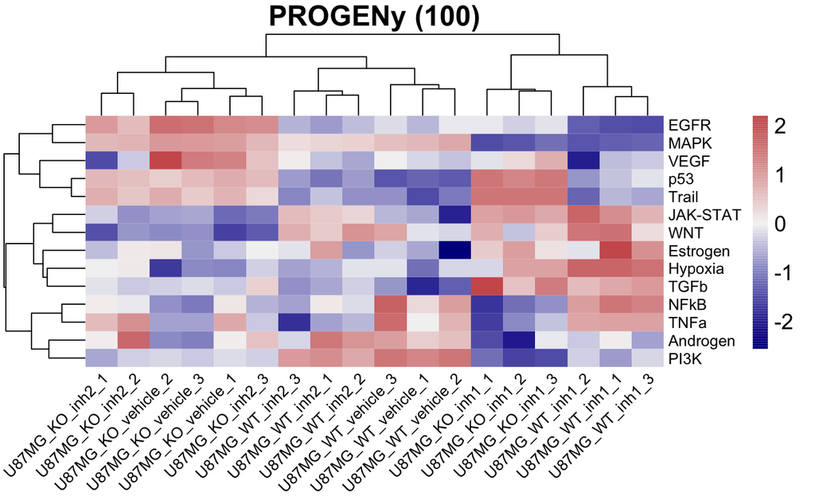

```r
paletteLength <- 100
myColor <-
    colorRampPalette(c("darkblue", "whitesmoke","indianred"))(paletteLength)

progenyBreaks <- c(seq(min(Activity_counts), 0,
    length.out=ceiling(paletteLength/2) + 1),
    seq(max(Activity_counts)/paletteLength,
    max(Activity_counts),
    length.out=floor(paletteLength/2)))

progeny_hmap <- pheatmap(t(progeny),fontsize=14,
    fontsize_row = 10, fontsize_col = 10,
    color=myColor, breaks = progenyBreaks,
    main = "PROGENy (100)", angle_col = 45,
    border_color = NA)
```

```r
quantile(progeny,
         c(0.1, 0.9), na.rm = TRUE) # doing this to determine relevant min and max value to cap colour scale for heat map
```

```
   10%    90%
-1.318  1.344
```

```r
col_fun <- colorRamp2(c(-1.3, 0, 1.3), viridis(3))
```

```r
ht_list <- Heatmap(t(progeny),
        name = "PROGENy Score",
        na_col = "black",
        column_title = "Samples",
    row_title = "Pathways",
    column_title_side = "bottom",
    column_title_gp = gpar(fontsize = 8, fontface = "bold"),
    row_title_gp = gpar(fontsize = 8, fontface = "bold"),
    column_names_gp = gpar(fontsize = 8),
    row_names_gp = gpar(fontsize = 5),
    border = TRUE,
    cluster_rows = TRUE, # must be FALSE if filtering on padj after rbind() above
    cluster_columns = TRUE, # must be FALSE if filtering on padj after rbind() above
    col = col_fun,
    use_raster = TRUE,
    raster_device = "png",
    show_row_names = TRUE
    )
pdf(paste0(output.figures, Sys.Date(),
           sep="_", "heatmap_PROGENy", ".pdf"), width = 5, height = 5)
draw(ht_list, heatmap_legend_side = "left")
dev.off()
```